# Metabolomics data processing

Max Qiu

February 18, 2022

# 1 Project and data background

# 2 Batch Correction

Batch correction using package `statTarget` evaluates the missing values and a feature will be kept if it has non-zero value for at least 50% of samples (`statTarget` default is 80%) in any one group. It then imputes missing values for the present features and QC-based signal correction. At last, it removes features CV% > 50% (default).

[output not shown]

[output not shown]

```
##
## * Step 5:  Removal of the features (CV% > 50%) Fri Feb 18 16:19:27 2022
##
##  No. of removed features: 18
##  Feature name: R.Y(+42.01)GGFMTSEKSQTPLVTLFKNAIIK.N R.R(+27.99)PVKVYPNVAENESAEAFPLEF.K T.LPVCS(-2.02)GGDC.Q L.SHYIHTLY.T L.PELFD(-18.01)RVVML.S P.SLQGVDEE.S D.DGVAELDQLLHY.R F.NPYFDPL.Q A.LLNKYGLL.V A.KAGCSPL.M L.SAASAPLAETSTPL.R S.SAVMALQEA.C E.SVFQELGKLTGPSNQ.K A.FPAMPLSSLFANAVLRAQHLHQLAA.D A.F…
##
##  Output Link: C:/Users/qiuha/Documents/sources/repos/MS-Workflow/scripts
##
##  Correction Finished! Time:  Fri Feb 18 16:19:27 2022
##
##  ####################################
##  # Software Version: statTarget 2.0 + #
##  ####################################
```

```
## After batch correction, there are 377 features left.
```

|  | Pituitary_08 | Pituitary_02 | Pituitary_19 | Pituitary_29 | Pituitary_04 | Pituitary_11 | Pituitary_34 | Pituitary_06 | Pituitary_18 | Pituitary_16 | Pituitary_31 | Pituitary_36 | Pituitary_07 | Pituitary_22 | Pituitary_27 | Pituitary_25 | Pituitary_32 | Pituitary_30 | Pituitary_35 | Pituitary_09 | Pituitary_05 | Pituitary_10 | Pituitary_12 | Pituitary_13 | Pituitary_28 | Pituitary_03 | Pituitary_21 | Pituitary_26 | Pituitary_15 | … |
| --- | --- | --- | --- | --- | --- | --- | --- | --- | --- | --- | --- | --- | --- | --- | --- | --- | --- | --- | --- | --- | --- | --- | --- | --- | --- | --- | --- | --- | --- | --- |
| class | Iso | SP | SP | SP | No | SP | Iso | No | Iso | Iso | No | Iso | Iso | SP | Iso | No | No | SP | Iso | Iso | No | SP | SP | No | SP | SP | SP | Iso | No | … |
| R.S..42.01.YSMEHFRWGKPV...98..G | 1917.60459 | 1818.45983 | 46.63987 | 742.87209 | 206.65302 | 138.73548 | 1944.02414 | 1397.28684 | 104.63198 | 962.19359 | 2175.67497 | 659.51618 | 355.12410 | 504.48538 | 1198.48644 | 620.04035 | 564.83766 | 541.14061 | 740.92412 | 841.69237 | 1222.37208 | 2550.91901 | 497.26545 | 1298.41535 | 1121.83944 | 1073.55967 | 1819.19546 | 1557.73771 | 980.50899 | … |
| R.RPVKVYPNVAENES..79.97.AEAFPLE.F | 4347.9192 | 1137.5097 | 101.7792 | 2705.5237 | 349.6099 | 695.6523 | 4847.7078 | 2725.7803 | 554.6900 | 4124.6179 | 3210.2762 | 2411.4143 | 1114.5781 | 2672.1175 | 1703.1079 | 2367.9014 | 1589.8509 | 1560.1340 | 1569.8435 | 3094.4571 | 2667.8370 | 5385.6959 | 551.2457 | 4120.0375 | 2097.3881 | 1319.9014 | 5418.5788 | 3278.1437 | 2779.9228 | … |
| R.RPVKVYPNVAENES..154.00.AEAFPLEF.K | 2334.33585 | 1098.84590 | 31.83588 | 1207.11047 | 1333.13652 | 2173.80124 | 2510.55521 | 1581.91583 | 1760.98064 | 7223.29639 | 1299.74574 | 1168.37992 | 1577.43044 | 4079.54898 | 3232.85014 | 5388.08356 | 971.62087 | 1314.02942 | 3400.67741 | 2511.23964 | 12524.39248 | 11430.55908 | 6566.07495 | 14123.25555 | 5240.14097 | 10729.18034 | 14992.37097 | 12588.53090 | 17693.91871 | … |
| R.YGGFMTSEKS..100.02.QTPLVTLFKNAIIKNVHKKG.Q | 1740.233618 | 865.913346 | 79.035733 | 463.511644 | 7.902901 | 307.563479 | 2662.652336 | 514.728554 | 781.262763 | 1436.206004 | 1572.018320 | 1028.565747 | 452.378454 | 82.859985 | 1065.790480 | 1285.217932 | 1131.379488 | 1998.173917 | 1085.389766 | 654.731297 | 256.912296 | 1443.046339 | 699.877197 | 690.741592 | 665.548545 | 564.440199 | 1429.535636 | 1250.843681 | 437.575894 | … |
| R.YGGFMTSEKSQTP..27.99.LVTLFKNAIIKNVHKKGQ | 1729.636743 | 835.310133 | 73.227476 | 428.777751 | 4.228324 | 296.554686 | 2694.776841 | 501.856716 | 756.035154 | 1404.079408 | 1557.624033 | 940.550973 | 401.693645 | 64.888009 | 892.819971 | 1097.729473 | 804.958421 | 1471.130906 | 560.245014 | 619.361043 | 250.214005 | 1805.811650 | 661.439740 | 2068.163694 | 679.586042 | 594.995599 | 1501.104559 | 1369.085591 | 427.392484 | … |
| R.RPVKVYPNVAENESAEAFPLE.F | 3618.5092 | 1529.3322 | 137.5435 | 2841.8072 | 151.9359 | 328.1170 | 4968.3211 | 2199.2686 | 362.5759 | 1778.0162 | 2746.3408 | 1421.4063 | 867.5871 | 1180.4429 | 1248.5453 | 1456.6362 | 983.6394 | 1105.0975 | 1218.6542 | 1331.8804 | 1102.4289 | 3872.0278 | 380.5480 | 1189.4257 | 1681.4521 | 800.6872 | 1751.1596 | 1664.6826 | 1224.8424 | … |
| R.YGGFMTSEKSQTPLVTLFK..109.05.NAIIKNV.H | 1746.57848 | 394.69249 | 711.81775 | 333.41012 | 28.19854 | 384.93245 | 1761.09575 | 881.70699 | 109.79451 | 2137.81323 | 1121.33776 | 1548.20990 | 621.44929 | 471.88665 | 492.93324 | 629.89334 | 808.18857 | 2397.64010 | 364.04818 | 1820.26671 | 701.89477 | 3920.60065 | 950.49148 | 2040.19635 | 232.78595 | 394.37390 | 1649.74278 | 748.63328 | 542.67392 | … |
| R.SYSMEHFRWGKPV...98..G | 1883.55262 | 810.05074 | 206.18456 | 372.49919 | 30.60099 | 79.85295 | 2044.65192 | 657.28834 | 110.62567 | 854.07348 | 1144.78759 | 398.64536 | 324.44954 | 350.40725 | 788.41631 | 515.70524 | 561.84362 | 640.85288 | 720.72986 | 1003.66764 | 750.23407 | 2216.07603 | 446.84537 | 1688.59304 | 1048.46381 | 372.94154 | 1384.37351 | 1078.60754 | 325.65982 | … |
| R.S..42.01.YSMEHFRWGKPVG.K | 1205.16413 | 782.38478 | 56.42979 | 935.68891 | 153.78192 | 284.99385 | 1331.89490 | 1182.73388 | 248.84738 | 1290.07221 | 1423.39275 | 998.04235 | 337.25596 | 693.76598 | 1498.61247 | 1498.05720 | 277.07795 | 711.67281 | 1278.27972 | 1094.03843 | 502.42852 | 893.59259 | 233.87218 | 831.72853 | 481.85322 | 299.08053 | 420.26718 | 1064.67686 | 371.61562 | … |

[output cut: 368 more lines]

The table below shows the number of missing values in the dataset at different stages of the workflow:

| Stage | No_of_missing |
| --- | --- |
| Raw file | 9074 |
| After batch correction | 0 |

## 2.1 Log2 transformation

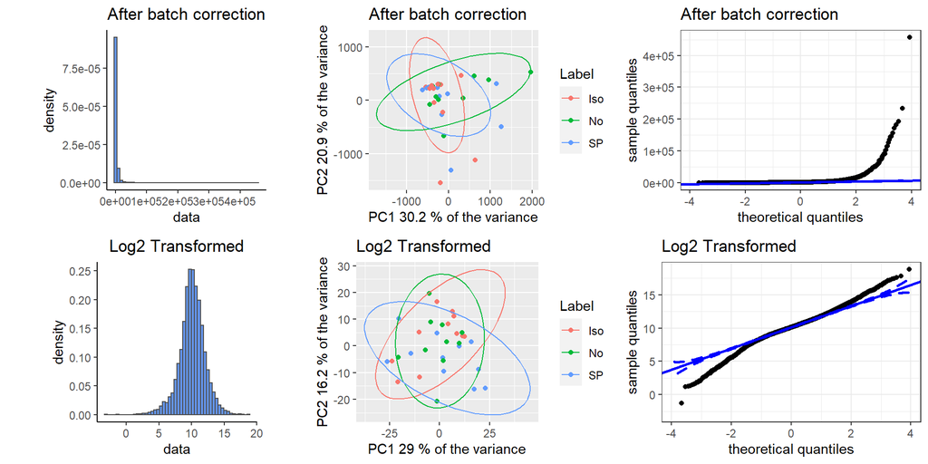

## 2.2 Peak intensity after log2 transformation

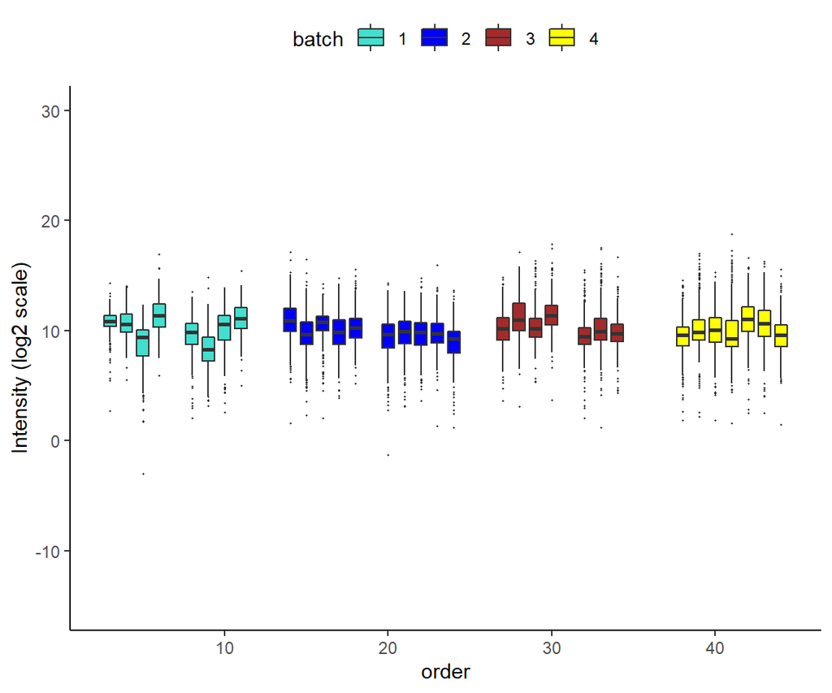

# 3 Normalization

## 3.1 EigenMS

**Data distribution**

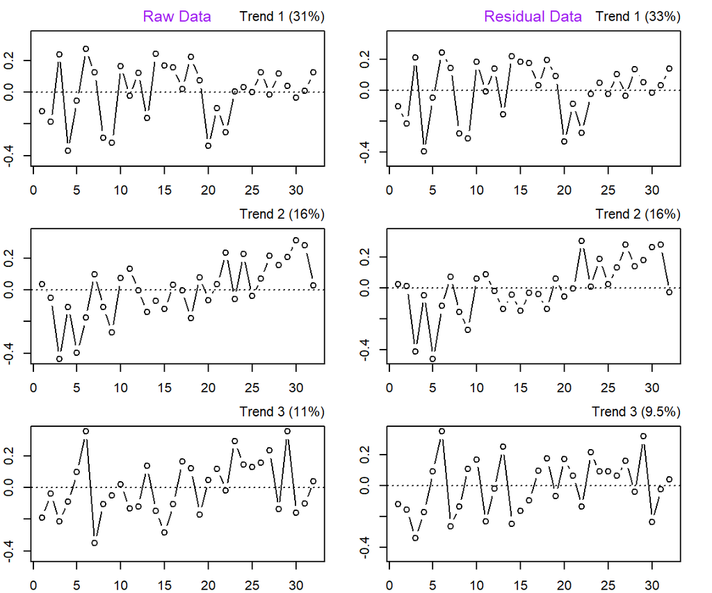

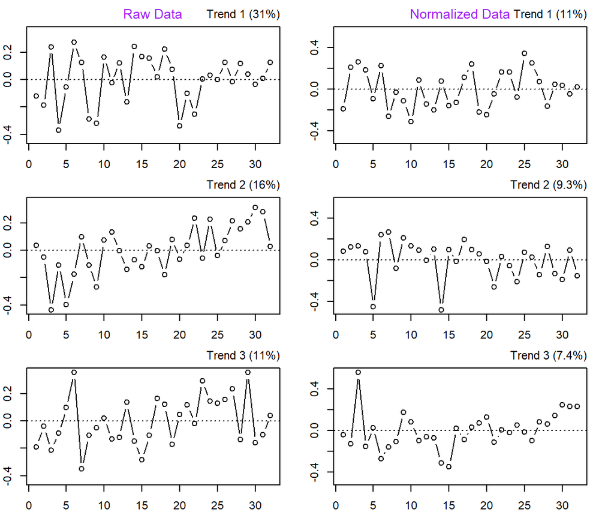

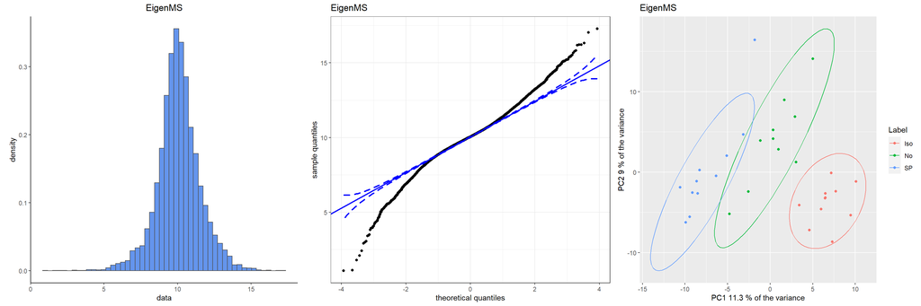

**Peak intensity**

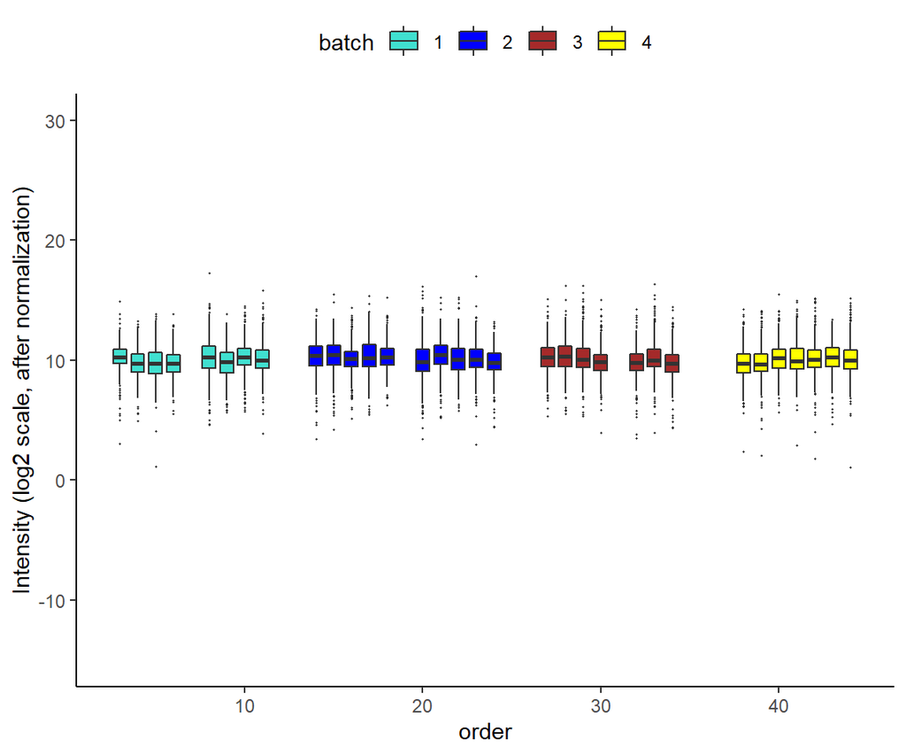

## 3.2 Cubic Spline

**Data distribution**

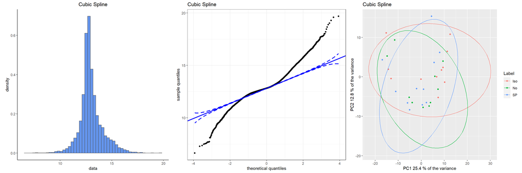

**Peak intensity**

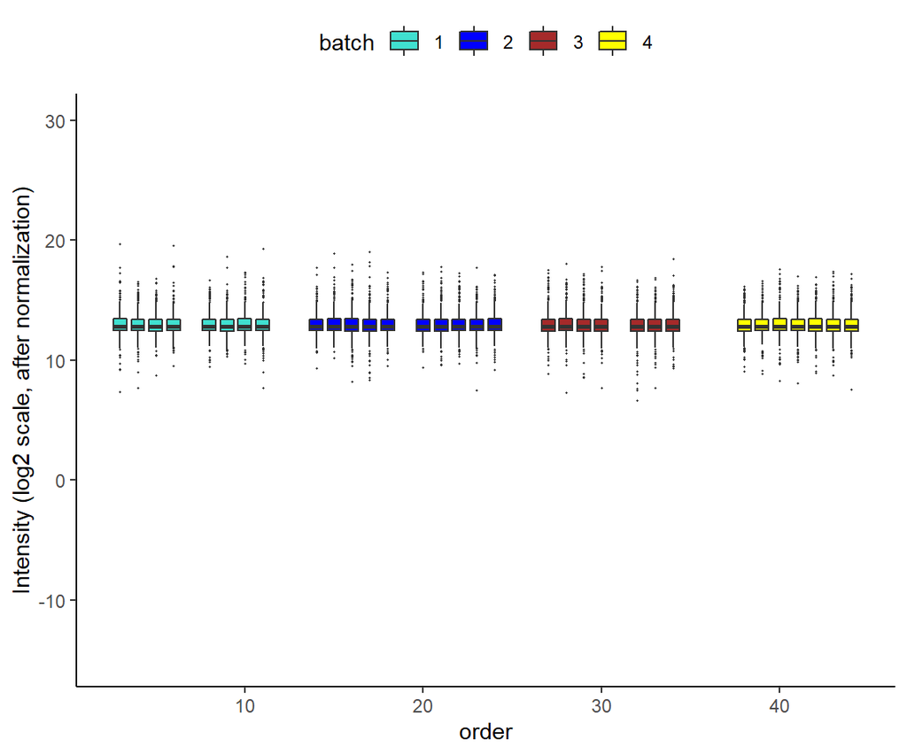

## 3.3 Invariant

**Data distribution**

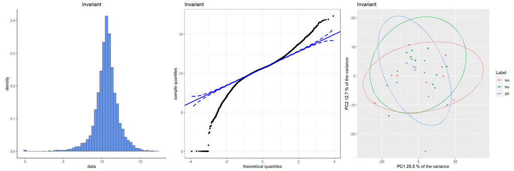

**Peak intensity**

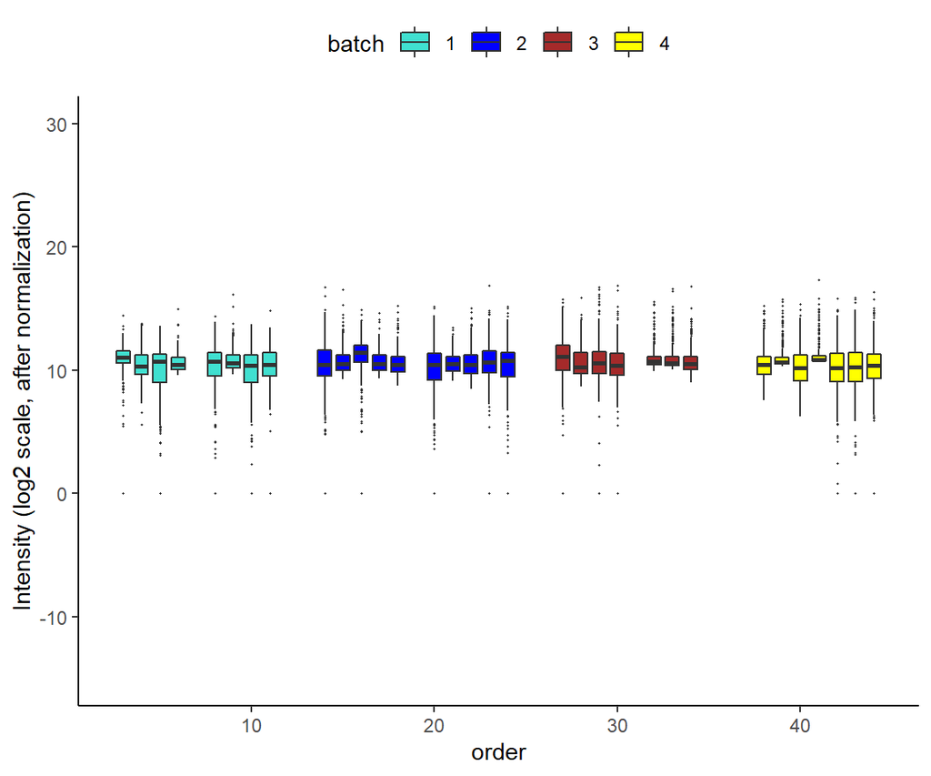

# 4 Pareto scaling

## 4.1 log2-pareto

**Data distribution**

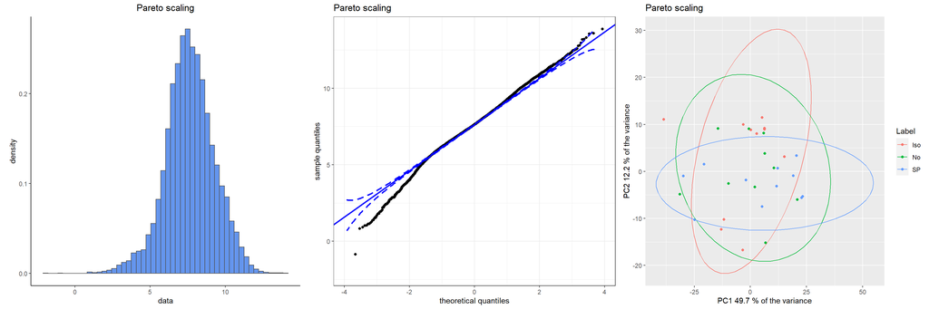

**Peak intensity**

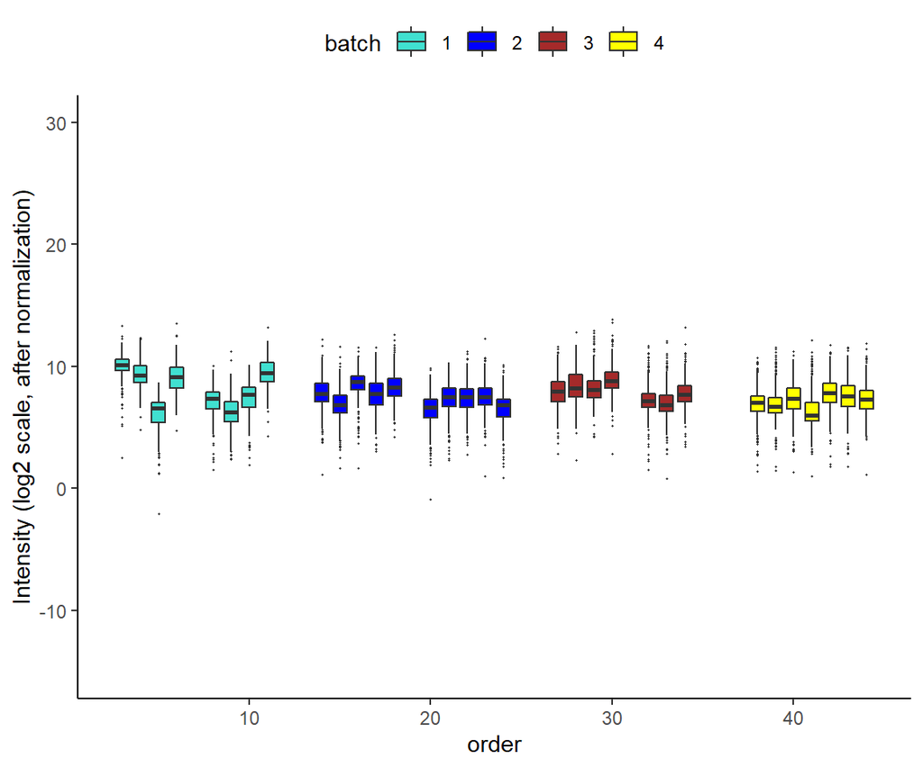

## 4.2 EigenMS-pareto

**Data distribution**

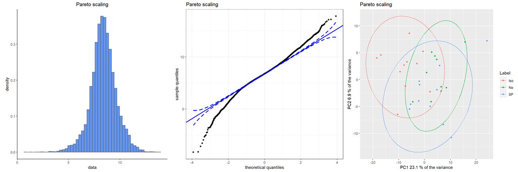

**Peak intensity**

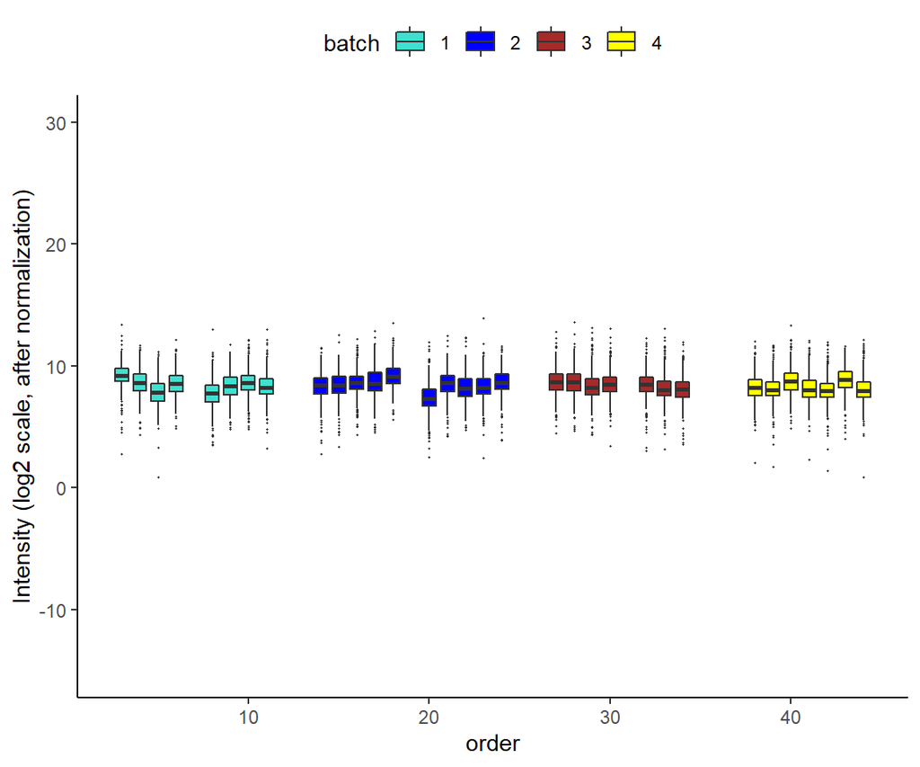

## 4.3 Cubic Spline-pareto

**Data distribution**

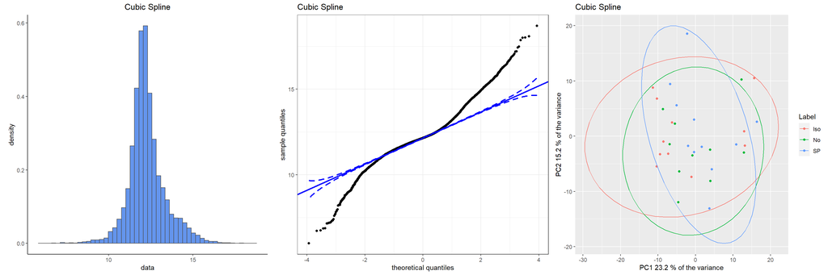

**Peak intensity**

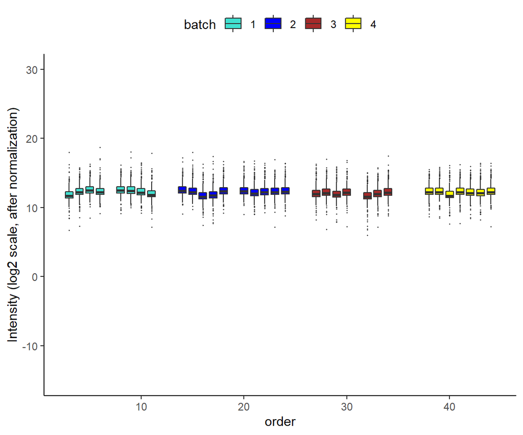

## 4.4 Invariant-pareto

**Data distribution**

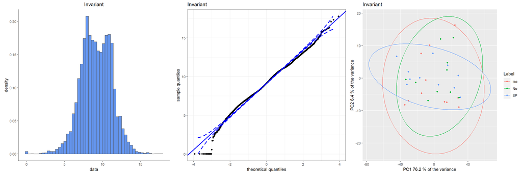

**Peak intensity**

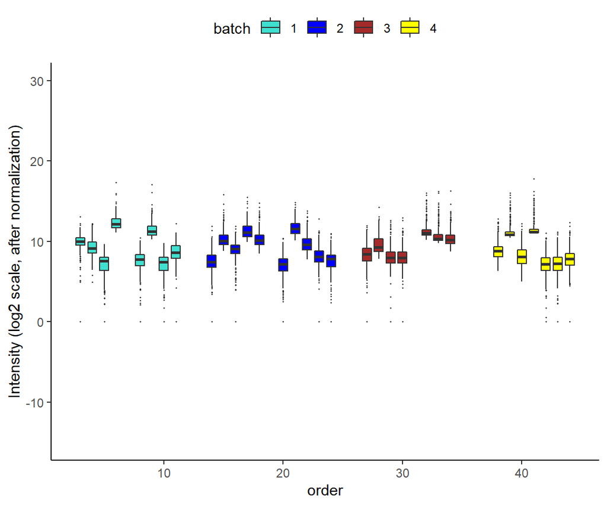

Choose data processing method to proceed with statistical analysis. In this case, choose `log2-EigenMS` dataset to proceed with statistical analysis.

# 5 Univariate analysis

Univariate statistic analysis will proceed for each pairs of comparison. For each pair,

Step 1, differential analysis;

- t-test
- Wilcoxon rank-sum test

`pT` and `BHT`, *p* values and adjusted *p* values for Student’s t-Test and `pW` and `BHW`, *p* values and adjusted *p* values for Wilcoxon Rank Sum Test.

Step 2, fold change, both linear and log2.